# FCA and the GDSTM

## GDSTM Decorrelation

This document describes the use of the **FRESA.CAD::GDSTMDecorrelation()** function that runs the feature correlation analysis (**FCA**) algorithm.

This scrip uses FRESA.CAD and mlbench R packages:

```r
knitr::opts_chunk$set(collapse = TRUE, warning = FALSE, message = FALSE,comment = "#>")

library("FRESA.CAD")
library(mlbench)

op <- par(no.readonly = TRUE)
```

```r
data("Satellite", package = "mlbench")
print(table(Satellite$classes))
```

```
           red soil         cotton crop           grey soil      damp grey soil  vegetation stubble very damp grey soil
               1533                 703                1358                 626                 707                1508
```

```r
soilnames <- names(table(Satellite$classes))
ncn <- c("RS","CC","GS","DGS","VS","VDGS")
names(ncn) <- soilnames
Satellite$classes <- as.factor(ncn[Satellite$classes])
print(table(Satellite$classes))
```

```
  CC  DGS   GS   RS VDGS   VS
 703  626 1358 1533 1508  707
```

Setting some variables for downstream analysis

```r
studyName = "Satellite"
datasetframe <- Satellite
Outcome <- "classes"

trainFraction = 0.75
correlationThreshold = 0.6
featnames <- colnames(datasetframe)[colnames(datasetframe) != Outcome]
```

Setting the Training and Testing sets

```r
tb <- table(datasetframe[,Outcome])
classNames <- unique(datasetframe[,Outcome])

allrowClass <- datasetframe[,Outcome]
names(allrowClass) <- rownames(datasetframe)

trainsize <- trainFraction*min(tb);
trainSamples <- NULL;
for (theClass in classNames)
{
  classSample <- allrowClass[allrowClass == theClass]
  trainSamples <- c(trainSamples,names(classSample[sample(length(classSample),trainsize)]))
}


datasetframe_train <- datasetframe[trainSamples,]
testSamples <- !(rownames(datasetframe) %in% trainSamples)
datasetframe_test <- datasetframe[testSamples,]

outcomes <- datasetframe_train[,Outcome]

pander::pander(table(datasetframe[,Outcome]),caption="All")
```

All

| CC | DGS | GS | RS | VDGS | VS |
| --- | --- | --- | --- | --- | --- |
| 703 | 626 | 1358 | 1533 | 1508 | 707 |

```r
pander::pander(table(datasetframe_train[,Outcome]),caption="Training")
```

Training

| CC | DGS | GS | RS | VDGS | VS |
| --- | --- | --- | --- | --- | --- |
| 469 | 469 | 469 | 469 | 469 | 469 |

```r
pander::pander(table(datasetframe_test[,Outcome]),caption="Testing")
```

Testing

| CC | DGS | GS | RS | VDGS | VS |
| --- | --- | --- | --- | --- | --- |
| 234 | 157 | 889 | 1064 | 1039 | 238 |

## FCA with default parameters

The default parameters will compute the transformation matrix with a maximum correlation goal of 0.8 using fast matrix multiplication with Pearson correlation and linear models estimation.

Default Parameters: thr=0.80,method=“fast”,type=“LM”

```r
datasetframeDecor<-list();
decortype <- list();
system.time(datasetframeDecor[[1]] <- GDSTMDecorrelation(datasetframe_train))
```

user system elapsed 0.14 0.00 0.14

```r
decortype[[1]] <- "Default"
```

We can decorrelate the testing set using the predict function

```r
decor_test <- predictDecorrelate(datasetframeDecor[[1]],datasetframe_test)
```

## Heat maps of the correlation matrices

Here are the heat maps of the correlation matrices before and after decorrelation on the testing set

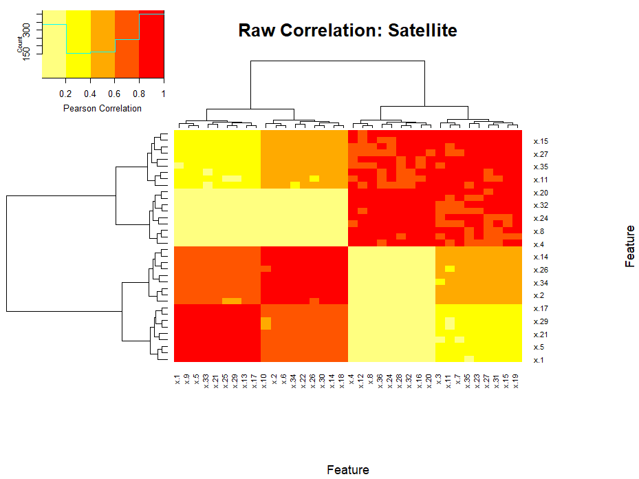

```r
featnames <- attr(datasetframeDecor[[1]],"varincluded")
cormat <- cor(datasetframe_test[,featnames],method="pearson")
gplots::heatmap.2(abs(cormat),
                  trace = "none",
                  scale = "none",
                  mar = c(10,10),
                  col=rev(heat.colors(5)),
                  main = paste("Raw Correlation:",studyName),
                  cexRow = 0.75,
                  cexCol = 0.75,
                  key.title=NA,
                  key.xlab="Pearson Correlation",
                  xlab="Feature", ylab="Feature")
```

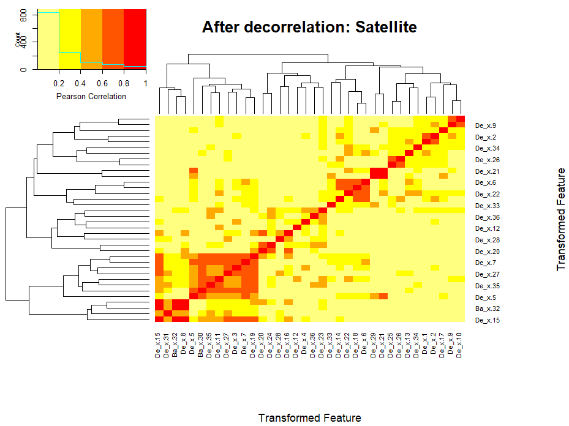

```r
featnames <- colnames(attr(datasetframeDecor[[1]],"GDSTM"))
cormat <- cor(decor_test[,featnames],method="pearson")
gplots::heatmap.2(abs(cormat),
                  trace = "none",
                  scale = "none",
                  mar = c(10,10),
                  col=rev(heat.colors(5)),
                  main = paste("After decorrelation:",studyName),
                  cexRow = 0.75,
                  cexCol = 0.75,
                  key.title=NA,
                  key.xlab="Pearson Correlation",
                  xlab="Transformed Feature", ylab="Transformed Feature")
```

```r
NA
NA
```

## FCA with Options

The following code runs the function and selecting some of the possible options:

```r
# Change the maximum correlation goal

decortype[[2]] <- "AtThr"
system.time(datasetframeDecor[[2]] <- GDSTMDecorrelation(
  datasetframe_train,
  thr = correlationThreshold
  ))
```

user system elapsed 0.24 0.00 0.22

```r
# Change the maximum correlation goal, and set to Robust Liner Models
decortype[[3]] <- "RLM_Pearson"
system.time(datasetframeDecor[[3]] <- GDSTMDecorrelation(
  datasetframe_train,
#  thr = correlationThreshold,
  type="RLM",
  method="pearson"))
```

user system elapsed 1.95 0.00 1.99

```r
# Change the maximum correlation goal, and change to Spearman correlation
decortype[[4]] <- "LM_Spearman"
system.time(datasetframeDecor[[4]] <- GDSTMDecorrelation(
  datasetframe_train,
#  thr = correlationThreshold,
  type="LM",
  method="spearman"))
```

user system elapsed 0.55 0.02 0.55

```r
# Change the maximum correlation goal, and set Spearman correlation with robust liner model
decortype[[5]] <- "RLM_Spearman"
system.time(datasetframeDecor[[5]] <- GDSTMDecorrelation(
  datasetframe_train,
#  thr = correlationThreshold,
  type="RLM",
  method="spearman"))
```

user system elapsed 1.88 0.03 1.93

```r
# The following are for supervised basis learning

# Set the target class for association learning
decortype[[6]] <- "Sup_Default"
system.time(datasetframeDecor[[6]] <- GDSTMDecorrelation(
  datasetframe_train,
  Outcome=Outcome))
```

user system elapsed 0.22 0.02 0.22

```r
# Change the maximum correlation goal
decortype[[7]] <- "Sup_AtThr"
system.time(datasetframeDecor[[7]] <- GDSTMDecorrelation(
  datasetframe_train,
#  thr = correlationThreshold,
  Outcome=Outcome))
```

user system elapsed 0.23 0.00 0.23

```r
# Change the maximum correlation goal, and set to Robust Liner Models
decortype[[8]] <- "Sup_RLM_Pearson"
system.time(datasetframeDecor[[8]] <- GDSTMDecorrelation(
  datasetframe_train,
#  thr = correlationThreshold,
  Outcome=Outcome,
  type="RLM",
  method="pearson"))
```

[output not shown]

The **GDSTMDecorrelation** function returns a data frame with the following column names:

The output features after transformation will be named after the original names and:

- The name will be unaltered if their maximum correlation to other features was lower than the threshold.
- The name will have the “Ba_” prefix is the feature was correlated but used as unaltered basis
- The name will have the “De_” prefix is the feature was original correlated and its correlation to “Ba_” features has been removed.

Furthermore, the returned data frame will have the following attributes:

1. Transformation matrix: “*GDSTM*”
2. Features:
   1. “*fsocre*”
   2. “*varincluded*”
   3. “*topFeatures*”
3. Unaltered Basis:
   1. “*baseFeatures*”
      1. “*correlatedToBase*”
   2. “*AbaseFeatures*”

### GDSTM

The “*GDSTM***“** attribute stores the spatial transformation matrix. The matrix only includes continuous features that had some correlation greater than the threshold

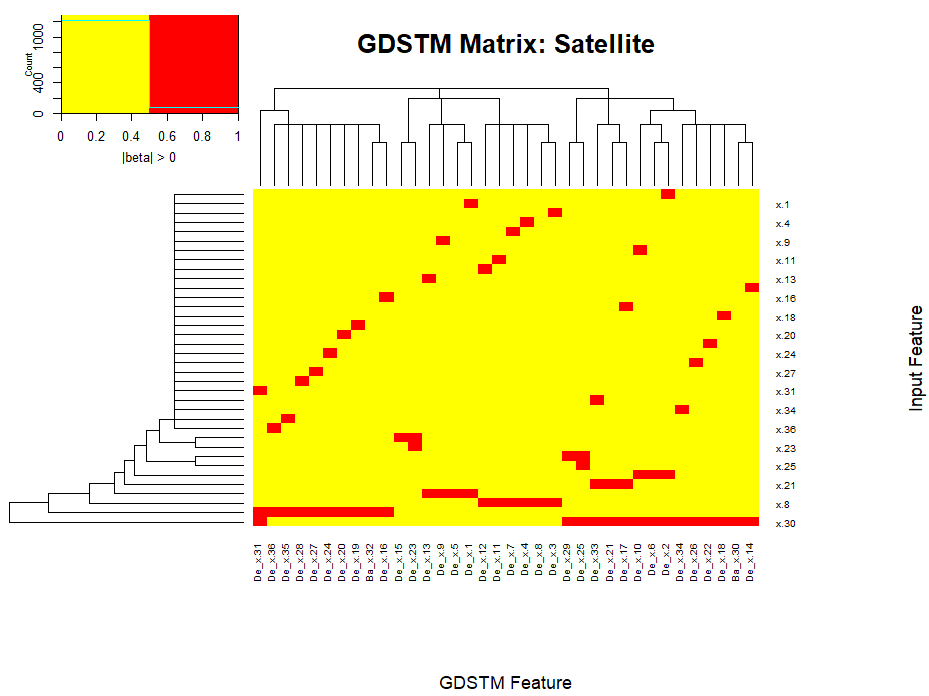

```r
## The Spatial Transformation Matrix:
GDSTM <- attr(datasetframeDecor[[1]],"GDSTM")

## The heatmap of the matrix
gplots::heatmap.2(1*(abs(GDSTM) > 0),
                  trace = "none",
                  mar = c(10,10),
                  col=rev(heat.colors(2)),
                  main = paste("GDSTM Matrix:",studyName),
                  cexRow = 0.7,
                  cexCol = 0.7,
                  breaks = c(0,0.5,1),
                  key.title=NA,
                  key.xlab="|beta| > 0",
                  xlab="GDSTM Feature", ylab="Input Feature")
```

```r
pander::pander(t(colnames(GDSTM)),caption="New names of decorrelated matrix")
```

New names of decorrelated matrix (continued below)

| De_x.1 | De_x.2 | De_x.3 | De_x.4 | De_x.5 | De_x.6 | De_x.7 | De_x.8 | De_x.9 |
| --- | --- | --- | --- | --- | --- | --- | --- | --- |

Table continues below

| De_x.10 | De_x.11 | De_x.12 | De_x.13 | De_x.14 | De_x.15 | De_x.16 | De_x.17 |
| --- | --- | --- | --- | --- | --- | --- | --- |

Table continues below

| De_x.18 | De_x.19 | De_x.20 | De_x.21 | De_x.22 | De_x.23 | De_x.24 | De_x.25 |
| --- | --- | --- | --- | --- | --- | --- | --- |

Table continues below

| De_x.26 | De_x.27 | De_x.28 | De_x.29 | Ba_x.30 | De_x.31 | Ba_x.32 | De_x.33 |
| --- | --- | --- | --- | --- | --- | --- | --- |

| De_x.34 | De_x.35 | De_x.36 |
| --- | --- | --- |

### The actual coefficients per each decorrelated feature

The following code extracts the dependence formula coefficients of each new feature to the original features.

```r
namecol <- colnames(GDSTM);

for (i in 1:ncol(GDSTM))
{
  associ <- abs(GDSTM[,i])>0;
  if (sum(associ) > 1)
  {
    pander::pander(t(GDSTM[associ,i]),caption=namecol[i])
  }
}
```

```
---------------
 x.1     x.5
----- ---------
  1    -0.9581
---------------

Table: De_x.1


-------------------------
 x.2     x.6      x.30
----- --------- ---------
  1    -0.8287   -0.1506
-------------------------

Table: De_x.2


---------------
 x.3     x.8
----- ---------
  1    -0.6374
---------------

Table: De_x.3


---------------
 x.4     x.8
----- ---------
  1    -0.9367
---------------

Table: De_x.4


-------------
 x.6   x.30
----- -------
  1    -0.85
```

[output cut: 222 more lines]

```
  x.32     x.35
--------- ------
 -0.6582    1
----------------

Table: De_x.35


----------------
  x.32     x.36
--------- ------
 -0.9519    1
----------------

Table: De_x.36
```

### The Feature Index Score

The **FCA** analysis of the data features are stored in three attributes: “*varincluded*”, “*topFeatures*”, and “*fscore*”.

- “varincluded” returns the list of continuous features that were decorrelated
- “topFeatures” returns the features that at some point were used as independent variables inside the linear models.
- “fscore” : returns a named vector with the total feature score, $F_j$, of the analyzed features.

$$F_j=∑_{n}∑_{i∈B^{n}_{j}}|ρ_{i,j}|^2(|ρ_{i,j}|>ρ_{th}),~ \forall j \in Ind$$

$$F_j=F_j-∑_{n}|ρ_{B^n_j,j}|^2),~ \forall j \in Dep$$

where $B^n_j$ is the set of features statistically associated with feature *j* at iteration *n,* $ρ_{i,j}$ is the correlation between features *i,j*, and $ρ_{th}$ is the correlation goal, ${Ind, Dep}$ are the set of independent and dependent features respectively. In other words, the “*fscore”* indicates the degree of total association of”independent” features to dependent features.

```r
pander::pander(t(attr(datasetframeDecor[[1]],"varincluded")),caption="Correlated Features")
```

Correlated Features (continued below)

| x.1 | x.2 | x.3 | x.4 | x.5 | x.6 | x.7 | x.8 | x.9 | x.10 | x.11 | x.12 |
| --- | --- | --- | --- | --- | --- | --- | --- | --- | --- | --- | --- |

Table continues below

| x.13 | x.14 | x.15 | x.16 | x.17 | x.18 | x.19 | x.20 | x.21 | x.22 | x.23 |
| --- | --- | --- | --- | --- | --- | --- | --- | --- | --- | --- |

| x.24 | x.25 | x.26 | x.27 | x.28 | x.29 | x.30 | x.31 | x.32 | x.33 | x.34 | x.35 | x.36 |
| --- | --- | --- | --- | --- | --- | --- | --- | --- | --- | --- | --- | --- |

```r
pander::pander(t(attr(datasetframeDecor[[1]],"topFeatures")),caption="Independent Features")
```

Independent Features

| x.30 | x.32 | x.5 | x.8 | x.6 | x.21 | x.29 | x.15 |
| --- | --- | --- | --- | --- | --- | --- | --- |

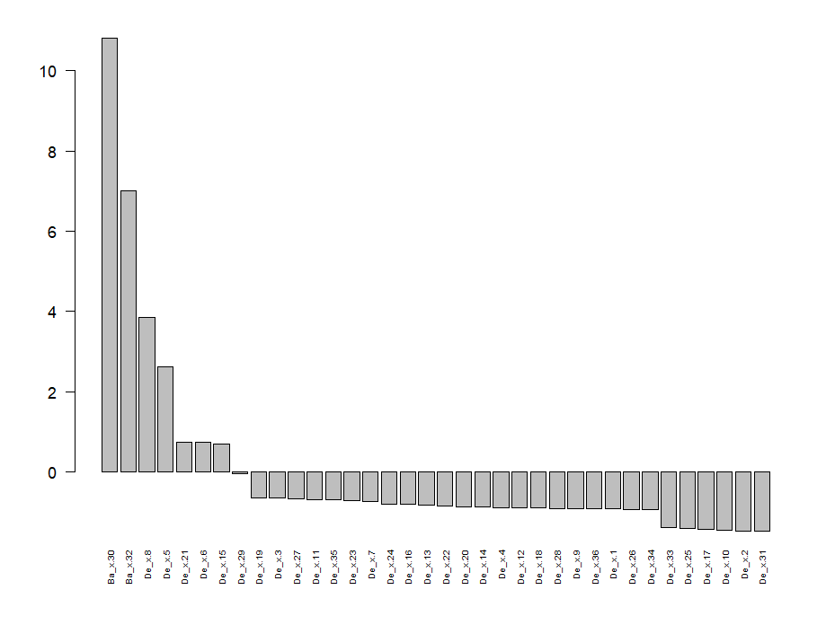

```r
fscore <- attr(datasetframeDecor[[1]],"fscore")
fscore <- fscore[order(-fscore)];
barplot(fscore,las=2,cex.names = 0.6)
```

The FCA algorithm will return for unsupervised basis learning the following attribute: “*AbaseFeatures*”

```r
pander::pander(t(attr(datasetframeDecor[[1]],"AbaseFeatures")),caption="Set of unaltered features")
```

Set of unaltered features

| x.30 | x.32 |
| --- | --- |

The total set of unaltered features is:

```r
atbase <- attr(datasetframeDecor[[1]],"AbaseFeatures")
featnames <- colnames(datasetframe_train)
included <- attr(datasetframeDecor[[1]],"varincluded")

notinvarincluded <-  featnames[!(featnames %in% included)]
pander::pander(t(c(atbase,notinvarincluded)),caption="Set of unaltered features")
```

Set of unaltered features

| x.30 | x.32 | classes |
| --- | --- | --- |

For supervised basis learning the FCA algorithm will return the following attributes:

- “*baseFeatures*” and “*correlatedToBase*”

The “*baseFeatures*” is the set of features that the **FRESA.CAD::univariate_correlation()** univariate filter function used to get the features associated with the outcome.

```r
# With Supervised Basis

pander::pander(t(attr(datasetframeDecor[[6]],"baseFeatures")),caption="Set of unaltered features")
```

Set of unaltered features

| x.2 | x.4 |
| --- | --- |

```r
if (length(attr(datasetframeDecor[[6]],"correlatedToBase"))>0)
{
pander::pander(t(attr(datasetframeDecor[[6]],"correlatedToBase")),caption="Set of features associated with base")
}
```

Set of features associated with base (continued below)

| x.1 | x.3 | x.5 | x.6 | x.7 | x.8 | x.10 | x.12 | x.13 | x.14 | x.16 | x.17 |
| --- | --- | --- | --- | --- | --- | --- | --- | --- | --- | --- | --- |

| x.18 | x.20 | x.22 | x.24 | x.26 | x.30 | x.34 |
| --- | --- | --- | --- | --- | --- | --- |

```r
atbaseSup <- attr(datasetframeDecor[[6]],"baseFeatures")
included <- attr(datasetframeDecor[[6]],"varincluded")

notinvarincludedSup <-  featnames[!(featnames %in% included)]
pander::pander(t(c(atbaseSup,notinvarincludedSup)),caption="Set of unaltered features: Supervised")
```

Set of unaltered features: Supervised

| x.2 | x.4 | classes |
| --- | --- | --- |

```r
pander::pander(t(c(atbase,notinvarincluded)),caption="Set of unaltered features: Unsupervised")
```

Set of unaltered features: Unsupervised

| x.30 | x.32 | classes |
| --- | --- | --- |

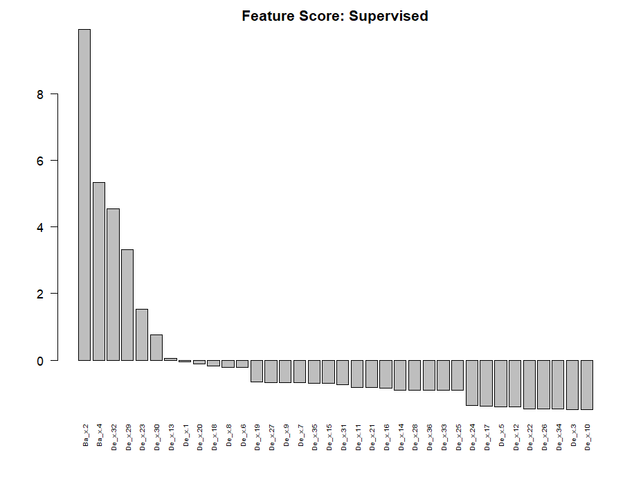

```r
fscore <- attr(datasetframeDecor[[6]],"fscore")
fscore <- fscore[order(-fscore)];
barplot(fscore,las=2,cex.names = 0.6,main="Feature Score: Supervised")
```

## Machine Learning and GDSTM

Train a simple NB model on the raw dataset

```r
mNBRaw <- filteredFit(paste(Outcome,"~."),
                   datasetframe_train,
                   fitmethod=NAIVE_BAYES,
                     filtermethod=univariate_Wilcoxon,
                     filtermethod.control=list(pvalue=0.05,limit= 0.2),
                     Scale="OrderLogit",
                     pca=FALSE
                   )

# With PCA
mNBPCA <- filteredFit(paste(Outcome,"~."),
                   datasetframe_train,
                   fitmethod=NAIVE_BAYES,
                     filtermethod=univariate_Wilcoxon,
                     filtermethod.control=list(pvalue=0.05,limit= 0.2),
                     Scale="OrderLogit",
                     pca=TRUE
                   )
```

Now using the decorrelated data

```r
mNBDecor <- filteredFit(paste(Outcome,"~."),
                   datasetframeDecor[[1]],
                    fitmethod=NAIVE_BAYES,
                     filtermethod=univariate_Wilcoxon,
                     filtermethod.control=list(pvalue=0.05,limit= 0.2),
                     Scale="OrderLogit",
                     pca=FALSE
                   )
```

To make predictions we need to transform the testing set. This is done using the **FRESA.CAD::predictDecorrelate()** function

```r
# Transform the testing set
decor_test <- predictDecorrelate(datasetframeDecor[[1]],datasetframe_test)
```

Once we have the transformed testing dataset we can make a side by side comparison of predictions

```r
# Predict the raw testing set
prRAW <- attr(predict(mNBRaw,datasetframe_test),"prob")

# Predict with PCA
prPCA <- attr(predict(mNBPCA,datasetframe_test),"prob")

# Predict the transformed dataset
prDecor <- attr(predict(mNBDecor,decor_test),"prob")


par(mfrow=c(1,3))
meanROCAUC <- numeric(3);
meanPCAROCAUC <- numeric(3);
for (theClass in classNames)
{
  classoutcomes <- 1*(datasetframe_test[,Outcome] == theClass)
  psRaw <- predictionStats_binary(cbind(classoutcomes,prRAW[,theClass]),
                                paste("Raw :",theClass),cex=0.75)
  pander::pander(psRaw$aucs)
  psPCA <- predictionStats_binary(cbind(classoutcomes,prPCA[,theClass]),
                                paste("PCA :",theClass),cex=0.75)
  pander::pander(psPCA$aucs)
  psDecor <- predictionStats_binary(cbind(classoutcomes,prDecor[,theClass]),
                                paste("GDSTM :",theClass),cex=0.75)
  pander::pander(psDecor$aucs)
  meanROCAUC <- meanROCAUC + psRaw$aucs;
  meanPCAROCAUC <- meanPCAROCAUC + psPCA$aucs;
}
```

Raw : GS

| est | lower | upper |
| --- | --- | --- |
| 0.9818 | 0.9775 | 0.9862 |

PCA : GS

| est | lower | upper |
| --- | --- | --- |
| 0.9859 | 0.9817 | 0.99 |

GDSTM : GS

| est | lower | upper |
| --- | --- | --- |
| 0.9816 | 0.9768 | 0.9863 |

Raw : DGS

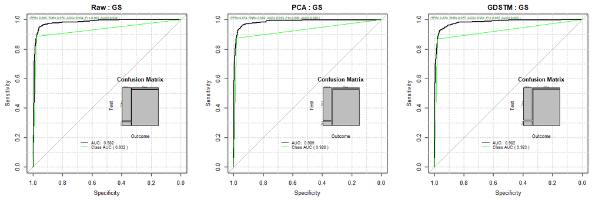

| est | lower | upper |
| --- | --- | --- |
| 0.9052 | 0.8854 | 0.9251 |

PCA : DGS

| est | lower | upper |
| --- | --- | --- |
| 0.8935 | 0.8712 | 0.9159 |

GDSTM : DGS

| est | lower | upper |
| --- | --- | --- |
| 0.8935 | 0.8681 | 0.9189 |

Raw : VS

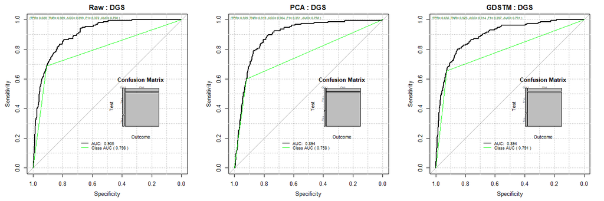

| est | lower | upper |
| --- | --- | --- |
| 0.9446 | 0.9308 | 0.9585 |

PCA : VS

| est | lower | upper |
| --- | --- | --- |
| 0.9534 | 0.9421 | 0.9647 |

GDSTM : VS

| est | lower | upper |
| --- | --- | --- |
| 0.9422 | 0.9282 | 0.9563 |

Raw : VDGS

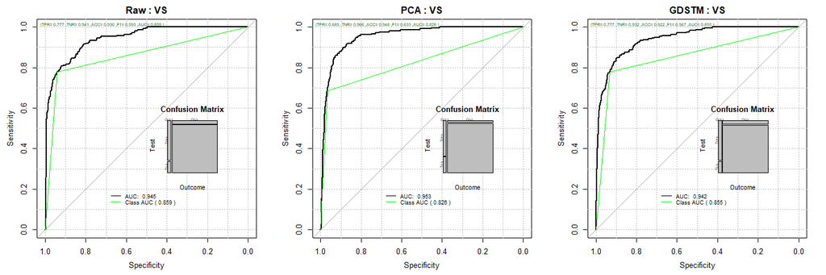

| est | lower | upper |
| --- | --- | --- |
| 0.9775 | 0.9738 | 0.9812 |

PCA : VDGS

| est | lower | upper |
| --- | --- | --- |
| 0.9607 | 0.9535 | 0.9679 |

GDSTM : VDGS

| est | lower | upper |
| --- | --- | --- |
| 0.9681 | 0.9628 | 0.9733 |

Raw : CC

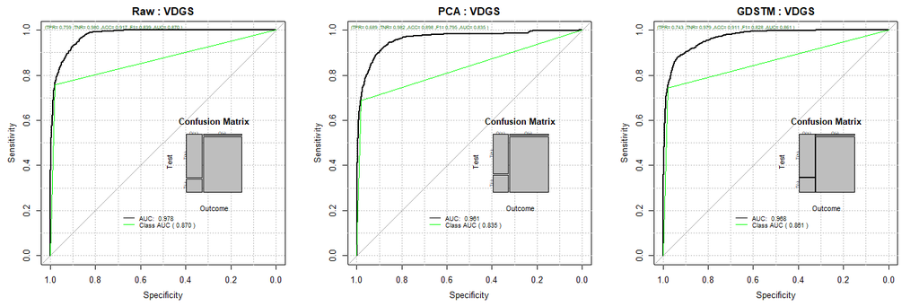

| est | lower | upper |
| --- | --- | --- |
| 0.9929 | 0.987 | 0.9988 |

PCA : CC

| est | lower | upper |
| --- | --- | --- |
| 0.9961 | 0.9943 | 0.9979 |

GDSTM : CC

| est | lower | upper |
| --- | --- | --- |
| 0.9963 | 0.9912 | 1 |

Raw : RS

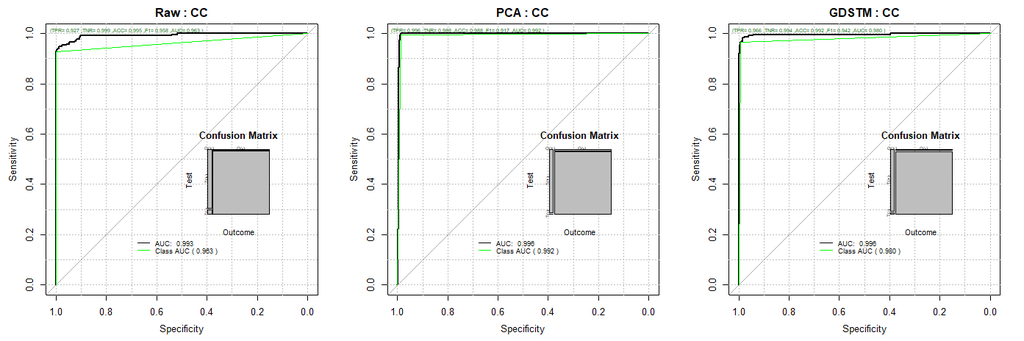

| est | lower | upper |
| --- | --- | --- |
| 0.9913 | 0.9889 | 0.9937 |

PCA : RS

| est | lower | upper |
| --- | --- | --- |
| 0.9837 | 0.9785 | 0.989 |

GDSTM : RS

| est | lower | upper |
| --- | --- | --- |
| 0.9871 | 0.9829 | 0.9914 |

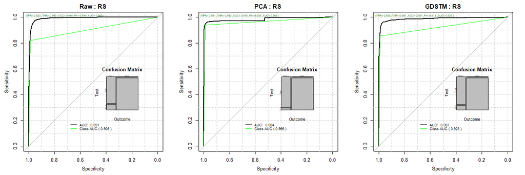

```r
meanROCAUC <- meanROCAUC/length(classNames)
AllRocAUC <- meanROCAUC;
meanPCAROCAUC <- meanPCAROCAUC/length(classNames)
AllRocAUC <- rbind(AllRocAUC,meanPCAROCAUC);
```

## Predict All Decorrelations

```r
par(mfrow=c(2,2))

for (i in c(1:length(datasetframeDecor)))
{
  mNBDecor <- filteredFit(paste(Outcome,"~."),
                   datasetframeDecor[[i]],
                    fitmethod=NAIVE_BAYES,
                     filtermethod=univariate_Wilcoxon,
                     filtermethod.control=list(pvalue=0.05,limit= 0.2),
                     Scale="OrderLogit",
                     pca=FALSE
                   )

  decor_test <- predictDecorrelate(datasetframeDecor[[i]],datasetframe_test)
  prDecor <- attr(predict(mNBDecor,decor_test),"prob")
  meanROCAUC <- numeric(3);
  for (theClass in classNames)
  {
    classoutcomes <- 1*(datasetframe_test[,Outcome] == theClass)
    psDecor <- predictionStats_binary(cbind(classoutcomes,prDecor[,theClass]),
                                  paste(decortype[[i]],theClass,sep=":"),cex=0.75)
    meanROCAUC <- meanROCAUC + psDecor$aucs;
  }
  meanROCAUC <- meanROCAUC/length(classNames)
  pander::pander(meanROCAUC)
  AllRocAUC <- rbind(AllRocAUC,meanROCAUC)

}
```

Default:GS Default:DGS Default:VS Default:VDGS Default:CC

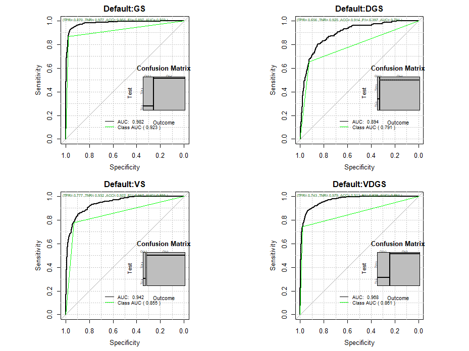

Default:RS

| est | lower | upper |
| --- | --- | --- |
| 0.9615 | 0.9517 | 0.971 |

AtThr:GS AtThr:DGS AtThr:VS

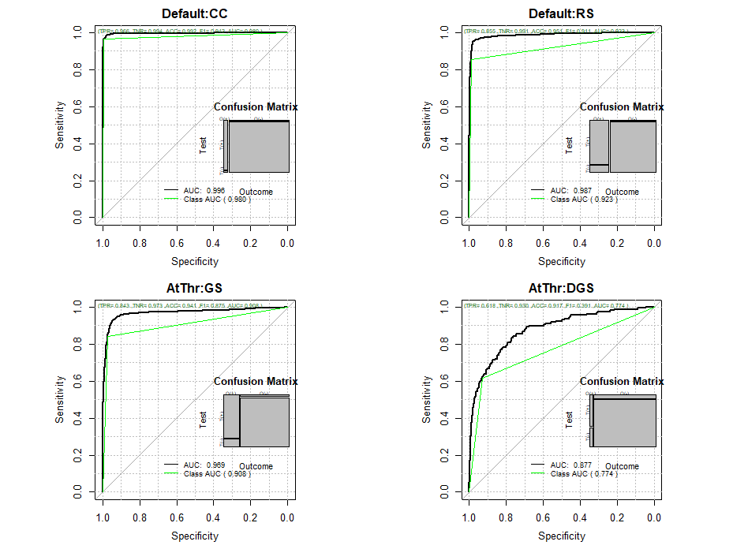

AtThr:VDGS AtThr:CC AtThr:RS

| est | lower | upper |
| --- | --- | --- |
| 0.9501 | 0.9375 | 0.9628 |

RLM_Pearson:GS

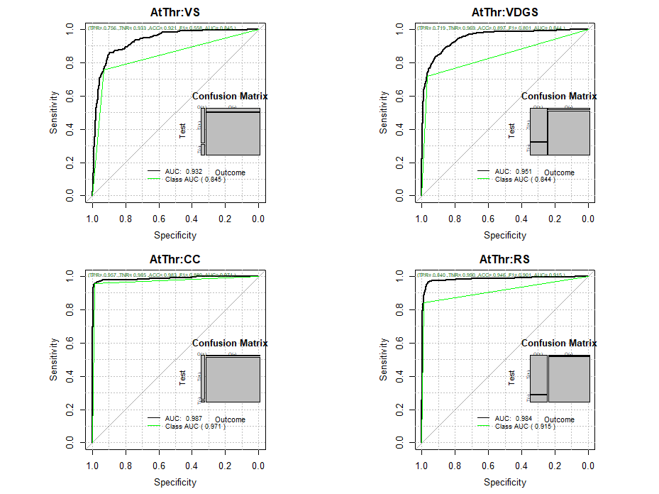

RLM_Pearson:DGS RLM_Pearson:VS RLM_Pearson:VDGS RLM_Pearson:CC

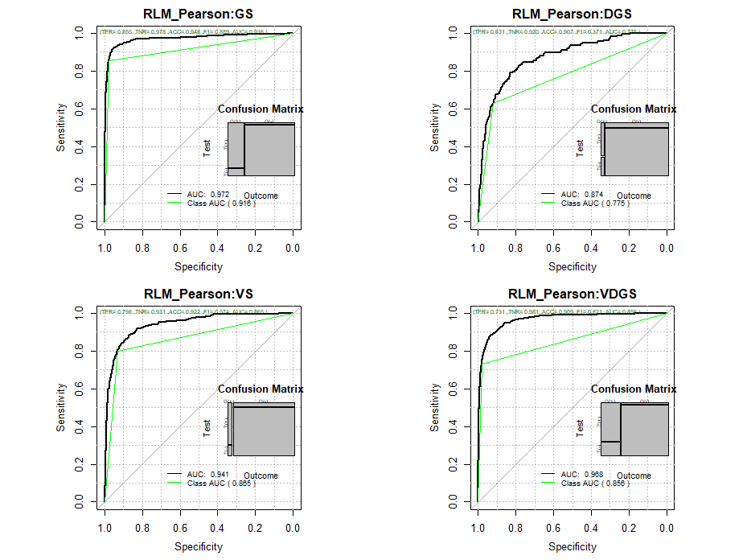

RLM_Pearson:RS

| est | lower | upper |
| --- | --- | --- |
| 0.9551 | 0.9435 | 0.9666 |

LM_Spearman:GS LM_Spearman:DGS LM_Spearman:VS

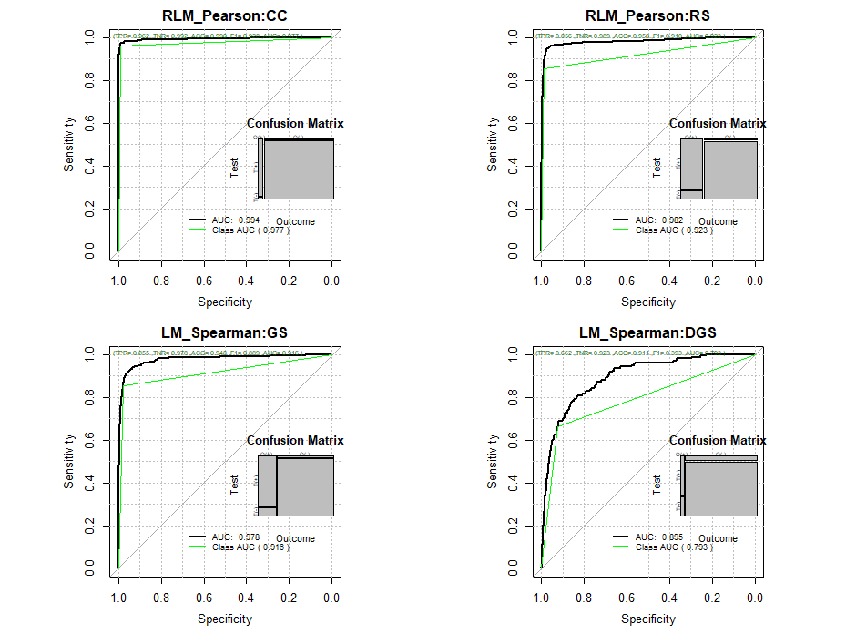

LM_Spearman:VDGS LM_Spearman:CC LM_Spearman:RS

| est | lower | upper |
| --- | --- | --- |
| 0.9605 | 0.9508 | 0.9701 |

RLM_Spearman:GS

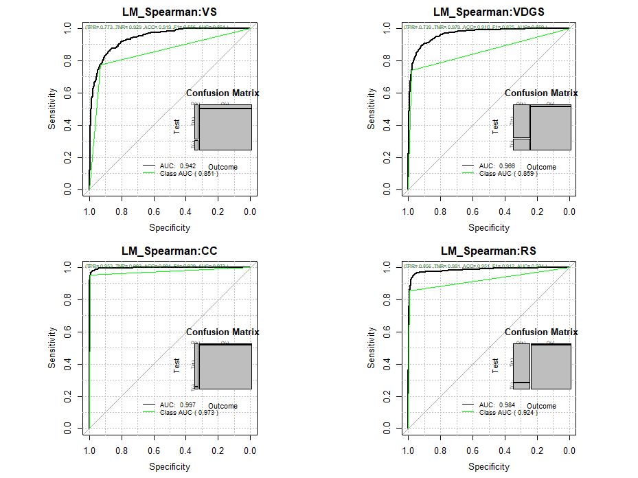

RLM_Spearman:DGS RLM_Spearman:VS RLM_Spearman:VDGS RLM_Spearman:CC

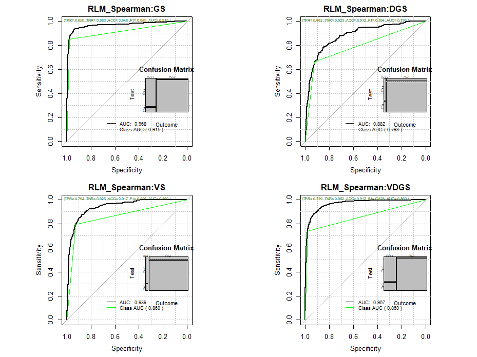

RLM_Spearman:RS

| est | lower | upper |
| --- | --- | --- |
| 0.9556 | 0.9445 | 0.9666 |

Sup_Default:GS Sup_Default:DGS Sup_Default:VS

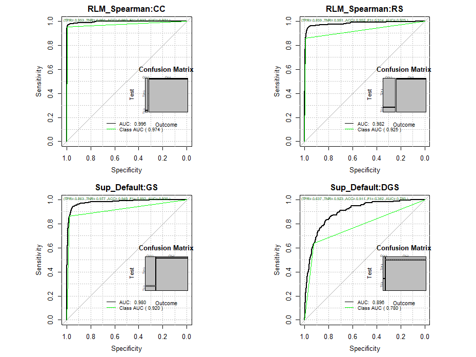

Sup_Default:VDGS Sup_Default:CC Sup_Default:RS

| est | lower | upper |
| --- | --- | --- |
| 0.9625 | 0.953 | 0.9719 |

Sup_AtThr:GS

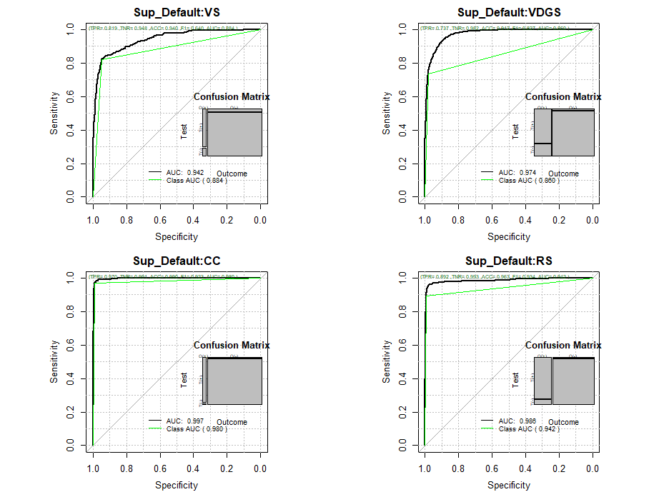

Sup_AtThr:DGS Sup_AtThr:VS Sup_AtThr:VDGS Sup_AtThr:CC

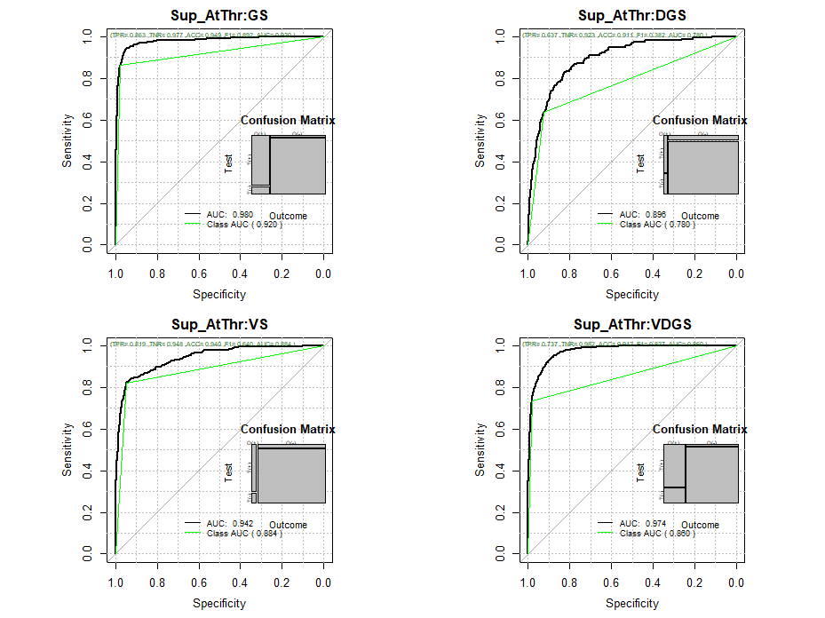

Sup_AtThr:RS

| est | lower | upper |
| --- | --- | --- |
| 0.9625 | 0.953 | 0.9719 |

Sup_RLM_Pearson:GS Sup_RLM_Pearson:DGS Sup_RLM_Pearson:VS

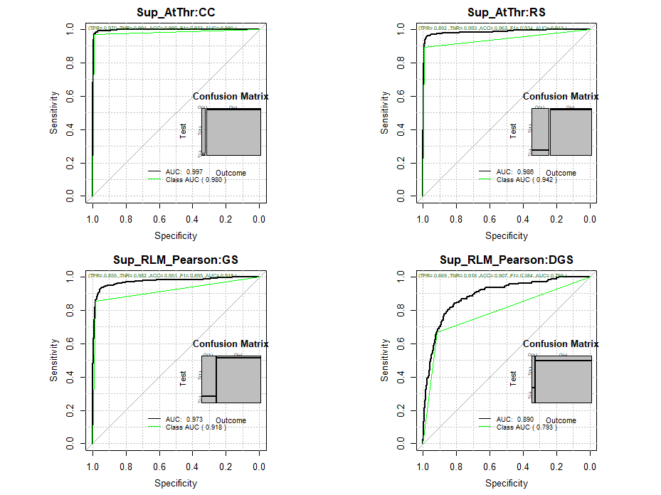

Sup_RLM_Pearson:VDGS Sup_RLM_Pearson:CC Sup_RLM_Pearson:RS

| est | lower | upper |
| --- | --- | --- |
| 0.9566 | 0.9456 | 0.9677 |

Sup_LM_Spearman:GS

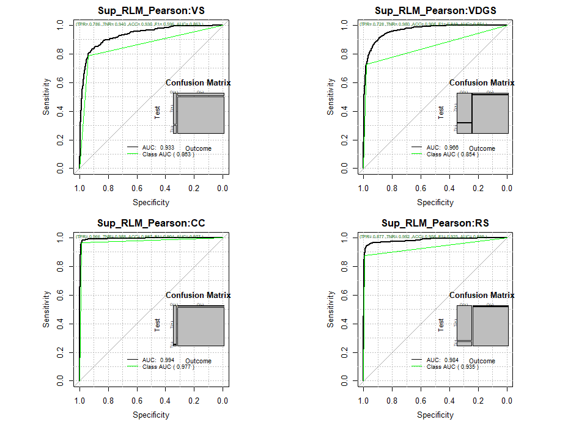

Sup_LM_Spearman:DGS Sup_LM_Spearman:VS Sup_LM_Spearman:VDGS Sup_LM_Spearman:CC

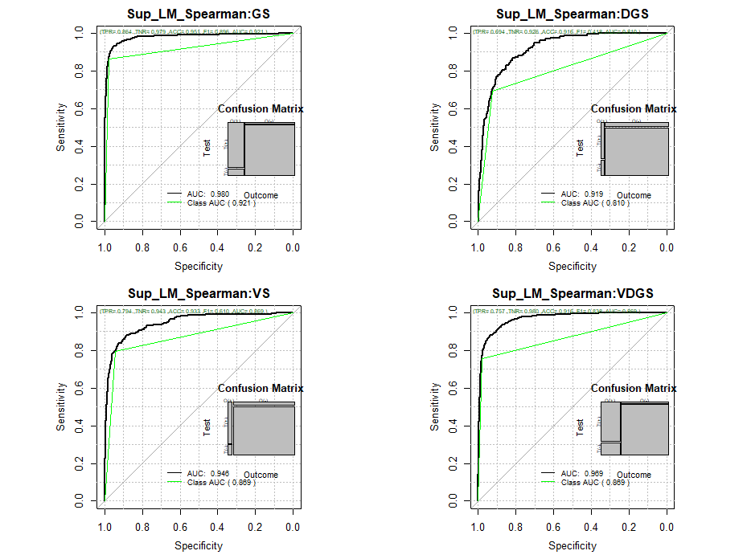

Sup_LM_Spearman:RS

| est | lower | upper |
| --- | --- | --- |
| 0.9658 | 0.9569 | 0.9746 |

Sup_RLM_Spearman:GS Sup_RLM_Spearman:DGS Sup_RLM_Spearman:VS

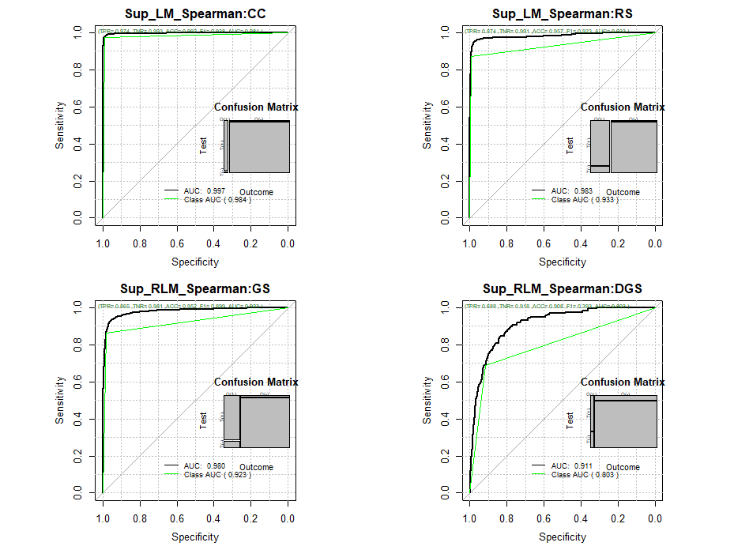

Sup_RLM_Spearman:VDGS Sup_RLM_Spearman:CC Sup_RLM_Spearman:RS

| est | lower | upper |
| --- | --- | --- |
| 0.9625 | 0.953 | 0.972 |

Sup_KS_RLM_Spearman:GS

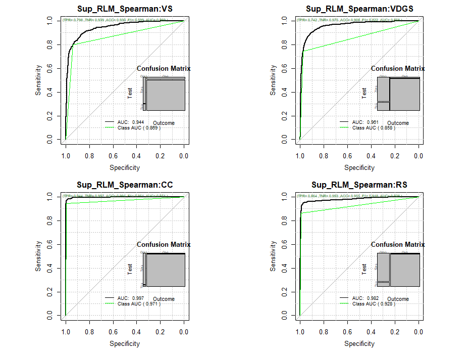

Sup_KS_RLM_Spearman:DGS Sup_KS_RLM_Spearman:VS Sup_KS_RLM_Spearman:VDGS Sup_KS_RLM_Spearman:CC

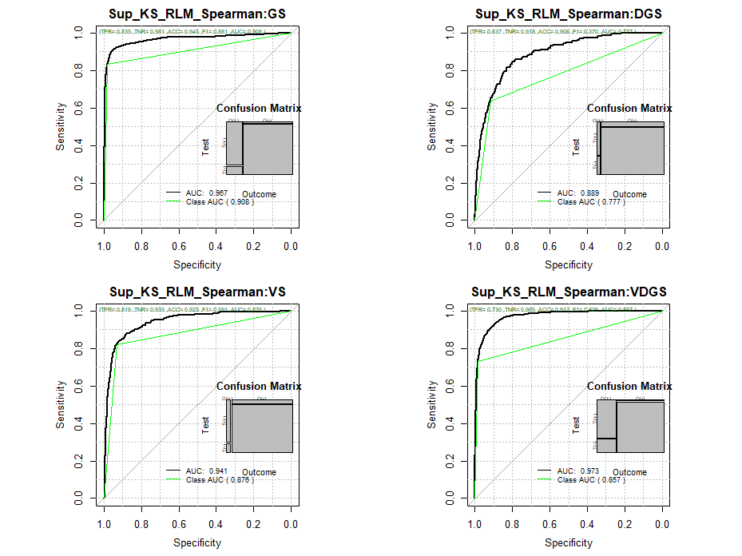

Sup_KS_RLM_Spearman:RS

| est | lower | upper |
| --- | --- | --- |
| 0.9581 | 0.9474 | 0.9688 |

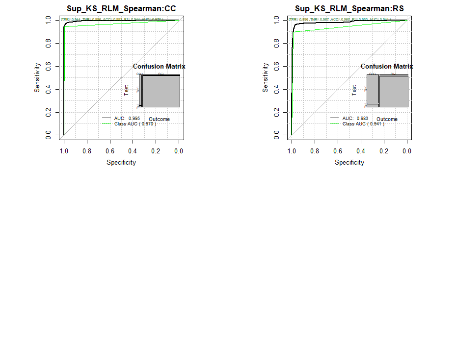

```r
rownames(AllRocAUC) <- c("Raw","PCA",unlist(decortype))
pander::pander(AllRocAUC)
```

|  | est | lower | upper |
| --- | --- | --- | --- |
| **Raw** | 0.9656 | 0.9572 | 0.9739 |
| **PCA** | 0.9622 | 0.9535 | 0.9709 |
| **Default** | 0.9615 | 0.9517 | 0.971 |
| **AtThr** | 0.9501 | 0.9375 | 0.9628 |
| **RLM_Pearson** | 0.9551 | 0.9435 | 0.9666 |
| **LM_Spearman** | 0.9605 | 0.9508 | 0.9701 |
| **RLM_Spearman** | 0.9556 | 0.9445 | 0.9666 |
| **Sup_Default** | 0.9625 | 0.953 | 0.9719 |
| **Sup_AtThr** | 0.9625 | 0.953 | 0.9719 |
| **Sup_RLM_Pearson** | 0.9566 | 0.9456 | 0.9677 |
| **Sup_LM_Spearman** | 0.9658 | 0.9569 | 0.9746 |
| **Sup_RLM_Spearman** | 0.9625 | 0.953 | 0.972 |
| **Sup_KS_RLM_Spearman** | 0.9581 | 0.9474 | 0.9688 |

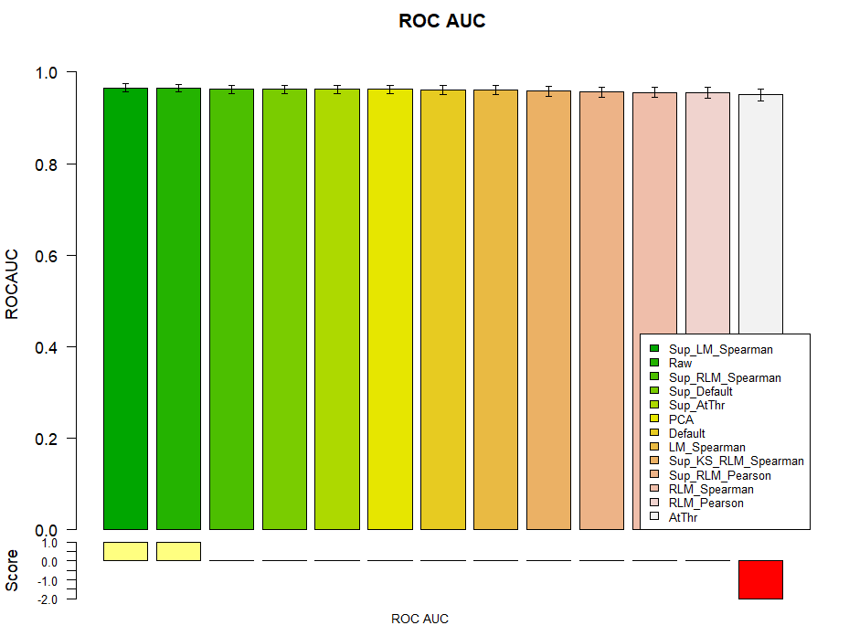

```r
bpROCAUC <- barPlotCiError(as.matrix(AllRocAUC),
                          metricname = "ROCAUC",
                          thesets = "ROC AUC",
                          themethod = rownames(AllRocAUC),
                          main = "ROC AUC",
                          offsets = c(0.5,1),
                          scoreDirection = ">",
                          ho=0.5,
                          args.legend = list(bg = "white",x="bottomright",inset=c(0.0,0),cex=0.75),
                          col = terrain.colors(nrow(AllRocAUC))
                          )
```